# Using SVM to build an indicator of Economic Development

We start by importing libraries and reading the data:

```python
import pandas as pd
import numpy as np
import matplotlib.pyplot as plt

import warnings
warnings.filterwarnings('ignore')
```

```python
data_hdi = pd.read_excel("HDI_data.xlsx")    #This file contains HDI data
```

The data present here contains HDI and its components: an education index, a health index, and an income index.

- *Education index* is an average of mean years of schooling (of adults) and expected years of schooling (of children). We here use the components of this index in a disaggregated way.
- The *life expectancy index* is given by life expectancy at birth expressed as an index using a minimum value of 20 years and a maximum value of 85 years.
- And the *income index* is given by GNI per capita (2017 PPP International USD, using natural logarithm) expressed as an index using a minimum value of USD 100 and a maximum value USD 75,000.

HDI data is available for the time period 1990-2019. However, we intend to expand the data to cover the 1900-2019 period instead. Therefore:

The compilation of this data is in the "databases" file.

*Note:* We will work with this file (databases) to analyze the SVM application with different kernels, but we will keep the file with the HDI data so that, in the end, we can compare the results (i.e. to understand if replacing the income index - GDP vs GNI - generates different results).

```python
databases = pd.read_excel("databases.xlsx")  #This file contains data with different databases
```

```python
# Correcting errors from the file:
databases['Av_education'] = pd.to_numeric(databases['Av_education'], errors='coerce')
databases['School_expectancy'] = pd.to_numeric(databases['School_expectancy'], errors='coerce')
databases['Life_expectancy_index'] = pd.to_numeric(databases['Life_expectancy_index'], errors='coerce')
databases['GDPpcLog'] = pd.to_numeric(databases['GDPpcLog'], errors='coerce')
databases['HDI_score'] = pd.to_numeric(databases['HDI_score'], errors='coerce')
```

```python
databases
```

|  | country | year | Av_education | School_expectancy | Life_expectancy_index | GDPpcLog | HDI_score |
| --- | --- | --- | --- | --- | --- | --- | --- |
| 0 | Afghanistan | 1900 | 0.025903 | 0.173368 | 0.153333 | NaN | NaN |
| 1 | Afghanistan | 1901 | 0.027107 | 0.179565 | 0.155000 | NaN | NaN |
| 2 | Afghanistan | 1902 | 0.028367 | 0.185984 | 0.155000 | NaN | NaN |
| 3 | Afghanistan | 1903 | 0.029685 | 0.192631 | 0.156667 | NaN | NaN |
| 4 | Afghanistan | 1904 | 0.031063 | 0.199517 | 0.156667 | NaN | NaN |
| ... | ... | ... | ... | ... | ... | ... | ... |
| 20230 | Zimbabwe | 2016 | 8.300000 | 10.400000 | 0.620000 | 0.649484 | 0.558 |
| 20231 | Zimbabwe | 2017 | 8.300000 | 10.500000 | 0.628000 | 0.682656 | 0.563 |
| 20232 | Zimbabwe | 2018 | 8.400000 | 10.500000 | 0.634000 | 0.702056 | 0.569 |
| 20233 | Zimbabwe | 2019 | 8.500000 | 11.000000 | 0.638000 | 0.689935 | 0.571 |
| 20234 | Zimbabwe | 2020 | NaN | NaN | NaN | NaN | NaN |

20235 rows × 7 columns

## Building the priming dataset

For the priming dataset, we assume that observations with an HDI above or equal to 0.8 correspond to countries with high development, and observations with an HDI below 0.55 correspond to less developed countries. We give a label = 1 to developed countries and 0 to less developed countries:

```python
is_developed = databases.HDI_score>=0.8
developedcountries=databases[is_developed]
developed=developedcountries[["country","year", "Av_education","School_expectancy",
                              "Life_expectancy_index","GDPpcLog"]]
developed['Label']=1
developed
```

|  | country | year | Av_education | School_expectancy | Life_expectancy_index | GDPpcLog | Label |
| --- | --- | --- | --- | --- | --- | --- | --- |
| 373 | Andorra | 2000 | 9.9 | 10.8 | 0.906 | NaN | 1 |
| 374 | Andorra | 2001 | 9.9 | 10.8 | 0.911 | NaN | 1 |
| 375 | Andorra | 2002 | 9.9 | 11.0 | 0.915 | NaN | 1 |
| 376 | Andorra | 2003 | 10.1 | 10.9 | 0.920 | NaN | 1 |
| 377 | Andorra | 2004 | 10.5 | 10.8 | 0.923 | NaN | 1 |
| ... | ... | ... | ... | ... | ... | ... | ... |
| 19560 | Uruguay | 2015 | 8.7 | 16.3 | 0.883 | 3.241006 | 1 |
| 19561 | Uruguay | 2016 | 8.7 | 16.6 | 0.885 | 3.252639 | 1 |
| 19562 | Uruguay | 2017 | 8.7 | 16.8 | 0.887 | 3.275614 | 1 |
| 19563 | Uruguay | 2018 | 8.8 | 16.8 | 0.889 | 3.289031 | 1 |
| 19564 | Uruguay | 2019 | 8.9 | 16.8 | 0.891 | 3.300816 | 1 |

1200 rows × 7 columns

```python
is_not_developed = databases.HDI_score<0.55
leastdevelopedcountries=databases[is_not_developed]
leastdeveloped=leastdevelopedcountries[["country","year", "Av_education","School_expectancy",
                                        "Life_expectancy_index","GDPpcLog"]]
leastdeveloped['Label']=0
leastdeveloped
```

|  | country | year | Av_education | School_expectancy | Life_expectancy_index | GDPpcLog | Label |
| --- | --- | --- | --- | --- | --- | --- | --- |
| 90 | Afghanistan | 1990 | 1.5 | 2.6 | 0.467 | 0.141676 | 0 |
| 91 | Afghanistan | 1991 | 1.6 | 2.9 | 0.477 | 0.042054 | 0 |
| 92 | Afghanistan | 1992 | 1.6 | 3.2 | 0.487 | -0.006866 | 0 |
| 93 | Afghanistan | 1993 | 1.7 | 3.6 | 0.496 | -0.448286 | 0 |
| 94 | Afghanistan | 1994 | 1.8 | 3.9 | 0.505 | -0.824432 | 0 |
| ... | ... | ... | ... | ... | ... | ... | ... |
| 20224 | Zimbabwe | 2010 | 7.3 | 10.1 | 0.471 | 0.552808 | 0 |
| 20225 | Zimbabwe | 2011 | 7.3 | 10.2 | 0.506 | 0.636146 | 0 |
| 20226 | Zimbabwe | 2012 | 7.9 | 10.3 | 0.539 | 0.697145 | 0 |
| 20227 | Zimbabwe | 2013 | 8.0 | 10.2 | 0.568 | 0.697145 | 0 |
| 20228 | Zimbabwe | 2014 | 8.2 | 10.3 | 0.591 | 0.690473 | 0 |

1371 rows × 7 columns

```python
#joining developed and undeveloped countries in the same table
frames=[developed,leastdeveloped]
table=pd.concat(frames)
table.dropna(inplace=True)
```

```python
table
```

|  | country | year | Av_education | School_expectancy | Life_expectancy_index | GDPpcLog | Label |
| --- | --- | --- | --- | --- | --- | --- | --- |
| 672 | Argentina | 2006 | 10.3 | 16.3 | 0.840 | 3.085717 | 1 |
| 673 | Argentina | 2007 | 10.3 | 16.3 | 0.843 | 3.167762 | 1 |
| 674 | Argentina | 2008 | 10.3 | 16.5 | 0.845 | 3.202470 | 1 |
| 675 | Argentina | 2009 | 10.3 | 16.8 | 0.848 | 3.135609 | 1 |
| 676 | Argentina | 2010 | 10.3 | 17.1 | 0.850 | 3.227119 | 1 |
| ... | ... | ... | ... | ... | ... | ... | ... |
| 20224 | Zimbabwe | 2010 | 7.3 | 10.1 | 0.471 | 0.552808 | 0 |
| 20225 | Zimbabwe | 2011 | 7.3 | 10.2 | 0.506 | 0.636146 | 0 |
| 20226 | Zimbabwe | 2012 | 7.9 | 10.3 | 0.539 | 0.697145 | 0 |
| 20227 | Zimbabwe | 2013 | 8.0 | 10.2 | 0.568 | 0.697145 | 0 |
| 20228 | Zimbabwe | 2014 | 8.2 | 10.3 | 0.591 | 0.690473 | 0 |

2394 rows × 7 columns

# Applying the SVM

```python
table1=table[["Av_education","School_expectancy",
              "Life_expectancy_index","GDPpcLog", "Label"]]

# Distinction between attributes and labels
X = table1.drop('Label', axis=1)
y = table1['Label']

# Dividing our data in training set and test set
from sklearn.model_selection import train_test_split
X_train, X_test, y_train, y_test = train_test_split(X, y, test_size = 0.20)
```

## Testing different kernels, for classification:

```python
# Linear SVM
from sklearn.svm import SVC
svclassifier = SVC(kernel='linear')
svclassifier.fit(X_train, y_train)

y_pred = svclassifier.predict(X_test)

from sklearn.metrics import classification_report, confusion_matrix
print(confusion_matrix(y_test,y_pred))
print(classification_report(y_test,y_pred))
```

```
[[259   0]
 [  0 220]]
              precision    recall  f1-score   support

           0       1.00      1.00      1.00       259
           1       1.00      1.00      1.00       220

    accuracy                           1.00       479
   macro avg       1.00      1.00      1.00       479
weighted avg       1.00      1.00      1.00       479
```

```python
# Polynomial
from sklearn.svm import SVC
svclassifier = SVC(kernel='poly', degree=2)
svclassifier.fit(X_train, y_train)

y_pred = svclassifier.predict(X_test)

from sklearn.metrics import classification_report, confusion_matrix
print(confusion_matrix(y_test, y_pred))
print(classification_report(y_test, y_pred))
```

```
[[259   0]
 [  0 220]]
              precision    recall  f1-score   support

           0       1.00      1.00      1.00       259
           1       1.00      1.00      1.00       220

    accuracy                           1.00       479
   macro avg       1.00      1.00      1.00       479
weighted avg       1.00      1.00      1.00       479
```

```python
# Gaussian
from sklearn.svm import SVC
svclassifier = SVC(kernel='rbf')
svclassifier.fit(X_train, y_train)

y_pred = svclassifier.predict(X_test)

from sklearn.metrics import classification_report, confusion_matrix
print(confusion_matrix(y_test, y_pred))
print(classification_report(y_test, y_pred))
```

```
[[259   0]
 [  0 220]]
              precision    recall  f1-score   support

           0       1.00      1.00      1.00       259
           1       1.00      1.00      1.00       220

    accuracy                           1.00       479
   macro avg       1.00      1.00      1.00       479
weighted avg       1.00      1.00      1.00       479
```

```python
# Sigmoid
from sklearn.svm import SVC
svclassifier = SVC(kernel='sigmoid')
svclassifier.fit(X_train, y_train)

y_pred = svclassifier.predict(X_test)

from sklearn.metrics import classification_report, confusion_matrix
print(confusion_matrix(y_test, y_pred))
print(classification_report(y_test, y_pred))
```

```
[[ 27 232]
 [220   0]]
              precision    recall  f1-score   support

           0       0.11      0.10      0.11       259
           1       0.00      0.00      0.00       220

    accuracy                           0.06       479
   macro avg       0.05      0.05      0.05       479
weighted avg       0.06      0.06      0.06       479
```

For classification, the sigmoid kernel performs very poorly, but the linear, polynomial and gaussian kernels work very well, with 100% prediction accuracy

## Applying different kernels in classification and comparing results with HDI

### Linear kernel:

```python
# Linear kernel:

from sklearn.svm import SVC
svclassifier = SVC(kernel='linear')
svclassifier.fit(X_train, y_train)

y_pred = svclassifier.predict(X_test)



Atrib=databases[["Av_education","School_expectancy","Life_expectancy_index","GDPpcLog"]]  #defines attributes
Atrib.dropna(inplace=True)                                     #drops NaNs, or else the SVM cannot be applied

Atrib_l=Atrib
Label_HDI_SVM_linear = svclassifier.predict(Atrib_l)                                 # Applies the classifier


#Creating a table with the attributes, the respective country-year information,
    #the classification from the SVC and the HDI score:
Atrib_l['Label_HDI_SVM_linear'] = Label_HDI_SVM_linear
Atrib_l['country']= databases.country
Atrib_l['year']= databases.year
Atrib_l['HDI_score']= databases.HDI_score
```

### Polynominal kernel:

```python
# Polynominal kernel:

from sklearn.svm import SVC
svclassifier = SVC(kernel='poly', degree=2)
svclassifier.fit(X_train, y_train)

y_pred = svclassifier.predict(X_test)

Atrib=databases[["Av_education","School_expectancy","Life_expectancy_index","GDPpcLog"]]  #defines attributes
Atrib.dropna(inplace=True)                                     #drops NaNs, or else the SVM cannot be applied

Atrib_poly=Atrib                                                                                  #attributes

Label_HDI_SVM_poly = svclassifier.predict(Atrib_poly)                                # Applies the classifier


#Creating a table with the attributes, the respective country-year information,
    #the classification from the SVC and the HDI score:
Atrib_poly['Label_HDI_SVM_poly'] = Label_HDI_SVM_poly
Atrib_poly['country']= databases.country
Atrib_poly['year']= databases.year
Atrib_poly['HDI_score']= databases.HDI_score
```

### Gaussian kernel:

```python
# Gaussian kernel:

from sklearn.svm import SVC
svclassifier = SVC(kernel='rbf')
svclassifier.fit(X_train, y_train)

y_pred = svclassifier.predict(X_test)


Atrib=databases[["Av_education","School_expectancy","Life_expectancy_index","GDPpcLog"]]  #defines attributes
Atrib.dropna(inplace=True)                                     #drops NaNs, or else the SVM cannot be applied
Atrib_rbf=Atrib

Label_HDI_SVM_rbf = svclassifier.predict(Atrib_rbf)                                  # Applies the classifier


#Creating a table with the attributes, the respective country-year information,
    #the classification from the SVC and the HDI score:
Atrib_rbf['Label_HDI_SVM_rbf'] = Label_HDI_SVM_rbf
Atrib_rbf['country']= databases.country
Atrib_rbf['year']= databases.year
Atrib_rbf['HDI_score']= databases.HDI_score
```

Note: The sigmoid kernel will not be applied, given the weak predictive capacity of this classifier.

#### Analyzing the correlation coefficients:

```python
c=Atrib[["HDI_score"]]
c['Linear classification']=Atrib_l.Label_HDI_SVM_linear
c['Gaussian classification']=Atrib_rbf.Label_HDI_SVM_rbf
c['Polynomial classification']=Atrib_poly.Label_HDI_SVM_poly


Correlation=c.corr()
print('Correlation between our binary classifiers and the original HDI scores:')
Correlation
```

```
Correlation between our binary classifiers and the original HDI scores:
```

|  | HDI_score | Linear classification | Gaussian classification | Polynomial classification |
| --- | --- | --- | --- | --- |
| HDI_score | 1.000000 | 0.820553 | 0.822313 | 0.815555 |
| Linear classification | 0.820553 | 1.000000 | 0.985479 | 0.976869 |
| Gaussian classification | 0.822313 | 0.985479 | 1.000000 | 0.968210 |
| Polynomial classification | 0.815555 | 0.976869 | 0.968210 | 1.000000 |

Our classifiers have a strong positive correlation (above 80%) with the HDI scores, with the Gaussian classifier having the highest correlation coefficient.

# Testing different kernels in regressions:

```python
#Linear Regression
from sklearn.svm import SVR
svregression_l = SVR(kernel='linear')
svregression_l.fit(X_train, y_train)

y_pred_l = svregression_l.predict(X_test)

accuracy_linear = svregression_l.score(X_test, y_test)
print("Accuracy of predictions with the linear regression: ", accuracy_linear)
```

```
Accuracy of predictions with the linear regression:  0.9239053012369964
```

```python
#Polynomial Regression
from sklearn.svm import SVR
svregression_p = SVR(kernel='poly', degree=2)
svregression_p.fit(X_train, y_train)

y_pred_p = svregression_p.predict(X_test)

accuracy_poly = svregression_p.score(X_test, y_test)
print("Accuracy of predictions with the polynomial regression (degree=2): ", accuracy_poly)
```

```
Accuracy of predictions with the polynomial regression (degree=2):  0.9371871645219617
```

```python
#Gaussian Regression
from sklearn.svm import SVR
svregression_g = SVR(kernel='rbf')
svregression_g.fit(X_train, y_train)

y_pred_g = svregression_g.predict(X_test)

accuracy_gauss = svregression_g.score(X_test, y_test)
print("Accuracy of predictions with the gaussian regression: ", accuracy_gauss)
```

```
Accuracy of predictions with the gaussian regression:  0.9833787842462866
```

The accuracy of predictions of the three kernels is very satisfactory (above 90%). The regressor that shows the best results is the one that uses the Gaussian kernel.

# Applying different kernels in regressions:

### Linear regression

```python
Atrib=databases[["Av_education","School_expectancy","Life_expectancy_index","GDPpcLog"]]  #defines attributes
Atrib.dropna(inplace=True)                                     #drops NaNs, or else the SVM cannot be applied

Atrib_linear_r=Atrib

Score_HDI_SVM_linear_r = svregression_l.predict(Atrib_linear_r)                # Applies the SVM (regression)


#Creating a table with the attributes, the respective country-year information,
    #the classification from the SVC and the HDI score:
Atrib_linear_r['Score_HDI_SVM_linear_r'] = Score_HDI_SVM_linear_r
Atrib_linear_r['country']= databases.country
Atrib_linear_r['year']= databases.year
Atrib_linear_r['HDI_score']= databases.HDI_score

table_final_linear_r=Atrib[["country","year","Av_education","School_expectancy","Life_expectancy_index",
                            "GDPpcLog","HDI_score","Score_HDI_SVM_linear_r"]]
```

### Polynomial Regression

```python
Atrib=databases[["Av_education","School_expectancy","Life_expectancy_index","GDPpcLog"]]  #defines attributes
Atrib.dropna(inplace=True)                                     #drops NaNs, or else the SVM cannot be applied

Atrib_poly_r=Atrib

Score_HDI_SVM_poly_r = svregression_p.predict(Atrib_poly_r)                     # Applies the SVM (regression)


#Creating a table with the attributes, the respective country-year information,
    #the classification from the SVC and the HDI score:
Atrib_poly_r['Score_HDI_SVM_poly_r'] = Score_HDI_SVM_poly_r
Atrib_poly_r['country']= databases.country
Atrib_poly_r['year']= databases.year
Atrib_poly_r['HDI_score']= databases.HDI_score

table_final_poly_r=Atrib[["country","year","Av_education","School_expectancy","Life_expectancy_index",
                          "GDPpcLog","HDI_score","Score_HDI_SVM_poly_r"]]
```

### Gaussian Regression

```python
Atrib=databases[["Av_education","School_expectancy","Life_expectancy_index","GDPpcLog"]]  #defines attributes
Atrib.dropna(inplace=True)                                     #drops NaNs, or else the SVM cannot be applied
Atrib_rbf_r=Atrib

Score_HDI_SVM_rbf_r = svregression_g.predict(Atrib_rbf_r)                       # Applies the SVM (regression)


#Creating a table with the attributes, the respective country-year information,
    #the classification from the SVC and the HDI score:
Atrib_rbf_r['Score_HDI_SVM_rbf_r'] = Score_HDI_SVM_rbf_r
Atrib_rbf_r['country']= databases.country
Atrib_rbf_r['year']= databases.year
Atrib_rbf_r['HDI_score']= databases.HDI_score

table_final_rbf_r=Atrib[["country","year","Av_education","School_expectancy","Life_expectancy_index",
                         "GDPpcLog","HDI_score","Score_HDI_SVM_rbf_r"]]
```

#### Analyzing the correlation coefficients:

```python
correlation=Atrib[["HDI_score"]]
correlation['Results from Linear regression']=table_final_linear_r.Score_HDI_SVM_linear_r
correlation['Results from Polynomial regression']=table_final_poly_r.Score_HDI_SVM_poly_r
correlation['Results from Gaussian regression']=table_final_rbf_r.Score_HDI_SVM_rbf_r

Correlation=correlation.corr()
print('Correlation between our countinuous indicators and the original HDI scores:')
Correlation
```

```
Correlation between our countinuous indicators and the original HDI scores:
```

|  | HDI_score | Results from Linear regression | Results from Polynomial regression | Results from Gaussian regression |
| --- | --- | --- | --- | --- |
| HDI_score | 1.000000 | 0.987949 | 0.971399 | 0.938678 |
| Results from Linear regression | 0.987949 | 1.000000 | 0.976499 | 0.874830 |
| Results from Polynomial regression | 0.971399 | 0.976499 | 1.000000 | 0.933962 |
| Results from Gaussian regression | 0.938678 | 0.874830 | 0.933962 | 1.000000 |

Our regressors have a strong positive correlation (above 90%) with the HDI scores, with the linear regressor having the highest correlation coefficient.

# Results

The indicator with the best results (in terms of accuracy) is the Gaussian:

```python
table_final_rbf_r
```

|  | country | year | Av_education | School_expectancy | Life_expectancy_index | GDPpcLog | HDI_score | Score_HDI_SVM_rbf_r |
| --- | --- | --- | --- | --- | --- | --- | --- | --- |
| 50 | Afghanistan | 1950 | 0.220 | 1.003679 | 0.200000 | 0.343504 | NaN | 0.070749 |
| 51 | Afghanistan | 1951 | 0.229 | 1.039555 | 0.206667 | 0.356675 | NaN | 0.070080 |
| 52 | Afghanistan | 1952 | 0.238 | 1.076713 | 0.216667 | 0.374276 | NaN | 0.069195 |
| 53 | Afghanistan | 1953 | 0.247 | 1.115200 | 0.228333 | 0.420045 | NaN | 0.066706 |
| 54 | Afghanistan | 1954 | 0.256 | 1.155061 | 0.240000 | 0.424421 | NaN | 0.066590 |
| ... | ... | ... | ... | ... | ... | ... | ... | ... |
| 20229 | Zimbabwe | 2015 | 8.200 | 10.300000 | 0.608000 | 0.667453 | 0.553 | 0.078423 |
| 20230 | Zimbabwe | 2016 | 8.300 | 10.400000 | 0.620000 | 0.649484 | 0.558 | 0.088206 |
| 20231 | Zimbabwe | 2017 | 8.300 | 10.500000 | 0.628000 | 0.682656 | 0.563 | 0.100472 |
| 20232 | Zimbabwe | 2018 | 8.400 | 10.500000 | 0.634000 | 0.702056 | 0.569 | 0.108277 |
| 20233 | Zimbabwe | 2019 | 8.500 | 11.000000 | 0.638000 | 0.689935 | 0.571 | 0.148028 |

11405 rows × 8 columns

We will now apply an SVM to HDI data only (which contains data for the period 1990-2019 and, for the income index, GNI is used instead of GDP). The purpose is to then compare these results with those of our indicator and see if the replacement of the income index and the different priming dataset (due to the existence of certain incompatibilities between the data from different sources) produce different results.

```python
#adjusting a few errors...
data_hdi['HDI_score'] = pd.to_numeric(data_hdi['HDI_score'], errors='coerce')

is_developed = data_hdi.HDI_score>=0.8
developedcountries=data_hdi[is_developed]
developed=developedcountries[["Country","Year", "Expected_years_of_schooling", "Mean_years_of_schooling",
                              "Life_expectancy_index", "Income_index"]]
developed['Label']=1

is_not_developed = data_hdi.HDI_score<0.55
leastdevelopedcountries=data_hdi[is_not_developed]
leastdeveloped=leastdevelopedcountries[["Country","Year", "Expected_years_of_schooling", "Mean_years_of_schooling",
                                        "Life_expectancy_index", "Income_index"]]
leastdeveloped['Label']=0

#joining developed and undeveloped countries in the same table
frames=[developed,leastdeveloped]
table=pd.concat(frames)

table.dropna(inplace=True)
table1=table[["Expected_years_of_schooling", "Mean_years_of_schooling", "Life_expectancy_index",
              "Income_index", "Label"]]

# Distinction between attributes and labels
X = table1.drop('Label', axis=1)
y = table1['Label']

# Dividing our data in training set and test set
from sklearn.model_selection import train_test_split
X_train, X_test, y_train, y_test = train_test_split(X, y, test_size = 0.20)

#Gaussian Regression
from sklearn.svm import SVR
svregression = SVR(kernel='rbf')
svregression.fit(X_train, y_train)

y_pred = svregression.predict(X_test)

data_hdi.dropna(inplace=True)
Atribu=data_hdi[["Expected_years_of_schooling", "Mean_years_of_schooling",
                 "Life_expectancy_index", "Income_index"]]

Atribu['Expected_years_of_schooling'] = pd.to_numeric(Atribu['Expected_years_of_schooling'], errors='coerce')
Atribu['Mean_years_of_schooling'] = pd.to_numeric(Atribu['Mean_years_of_schooling'], errors='coerce')
Atribu['Life_expectancy_index'] = pd.to_numeric(Atribu['Life_expectancy_index'], errors='coerce')
Atribu['Income_index'] = pd.to_numeric(Atribu['Income_index'], errors='coerce')
Atribu.dropna(inplace=True)

Score = svregression.predict(Atribu)

final_gaussian=data_hdi [["Country","Year", "Expected_years_of_schooling", "Mean_years_of_schooling",
                          "Life_expectancy_index", "Income_index","HDI_score"]]
final_gaussian['Score_2'] = Score
```

Let us see the evolution of the indicators (our indicator, the indicator using only HDI data, and the HDI scores) for some countries:

### Portugal

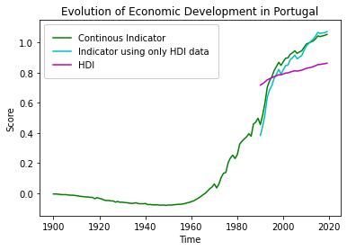

```python
is_Portugal= table_final_rbf_r.country=="Portugal"
Portugal=table_final_rbf_r[is_Portugal]

is_Portugal2= final_gaussian.Country==" Portugal"
Portugal2=final_gaussian[is_Portugal2]


plt.plot(Portugal.year, Portugal.Score_HDI_SVM_rbf_r, 'g', label="Continous Indicator")
plt.plot(Portugal2.Year, Portugal2.Score_2, 'c', label="Indicator using only HDI data")
plt.plot(Portugal.year, Portugal.HDI_score, 'm', label="HDI")
plt.legend(fancybox=True, framealpha=1, borderpad=1)
plt.title('Evolution of Economic Development in Portugal')
plt.xlabel('Time')
plt.ylabel('Score')
plt.ylim((-0.15,1.15))
```

### United States of America

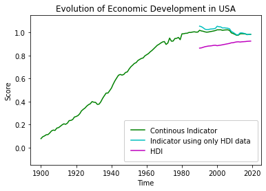

```python
is_USA= table_final_rbf_r.country=="United States of America"
USA=table_final_rbf_r[is_USA]

is_USA2= final_gaussian.Country==" United States"
USA2=final_gaussian[is_USA2]


plt.plot(USA.year, USA.Score_HDI_SVM_rbf_r, 'g', label="Continous Indicator")
plt.plot(USA2.Year, USA2.Score_2, 'c', label="Indicator using only HDI data")
plt.plot(USA.year, USA.HDI_score, 'm', label="HDI")
plt.legend(fancybox=True, framealpha=1, borderpad=1)
plt.title('Evolution of Economic Development in USA')
plt.xlabel('Time')
plt.ylabel('Score')
plt.ylim((-0.15,1.15))
```

### India

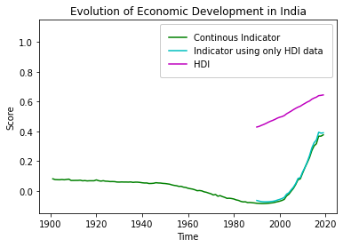

```python
is_India= table_final_rbf_r.country=="India"
India=table_final_rbf_r[is_India]

is_India2= final_gaussian.Country==" India"
India2=final_gaussian[is_India2]


plt.plot(India.year, India.Score_HDI_SVM_rbf_r, 'g', label="Continous Indicator")
plt.plot(India2.Year, India2.Score_2, 'c', label="Indicator using only HDI data")
plt.plot(India.year, India.HDI_score, 'm', label="HDI")
plt.legend(fancybox=True, framealpha=1, borderpad=1)
plt.title('Evolution of Economic Development in India')
plt.xlabel('Time')
plt.ylabel('Score')
plt.ylim((-0.15,1.15))
```

### South Africa

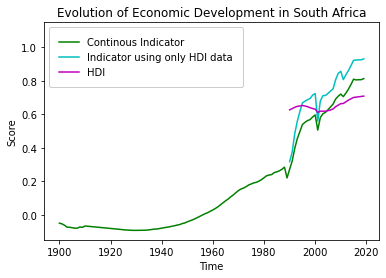

```python
is_South_Africa= table_final_rbf_r.country=="South Africa"
South_Africa=table_final_rbf_r[is_South_Africa]

is_South_Africa2= final_gaussian.Country==" South Africa"
South_Africa2=final_gaussian[is_South_Africa2]


plt.plot(South_Africa.year, South_Africa.Score_HDI_SVM_rbf_r, 'g', label="Continous Indicator")
plt.plot(South_Africa2.Year, South_Africa2.Score_2, 'c', label="Indicator using only HDI data")
plt.plot(South_Africa.year, South_Africa.HDI_score, 'm', label="HDI")
plt.legend(fancybox=True, framealpha=1, borderpad=1)
plt.title('Evolution of Economic Development in South Africa')
plt.xlabel('Time')
plt.ylabel('Score')
plt.ylim((-0.15,1.15))
```

### Russia

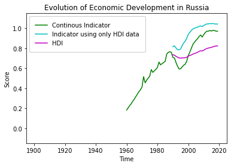

```python
is_Russia= table_final_rbf_r.country=="Russia"
Russia=table_final_rbf_r[is_Russia]

is_Russia2= final_gaussian.Country==" Russian Federation"
Russia2=final_gaussian[is_Russia2]


plt.plot(Russia.year, Russia.Score_HDI_SVM_rbf_r, 'g', label="Continous Indicator")
plt.plot(Russia2.Year, Russia2.Score_2, 'c', label="Indicator using only HDI data")
plt.plot(Russia.year, Russia.HDI_score, 'm', label="HDI")
plt.legend(fancybox=True, framealpha=1, borderpad=1)
plt.title('Evolution of Economic Development in Russia')
plt.xlabel('Time')
plt.ylabel('Score')
plt.ylim((-0.15,1.15))
plt.xlim((1895,2025))
```

### Chile

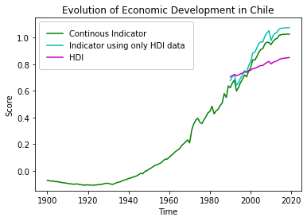

```python
is_Chile = table_final_rbf_r.country=="Chile"
Chile=table_final_rbf_r[is_Chile]

is_Chile2= final_gaussian.Country==" Chile"
Chile2=final_gaussian[is_Chile2]


plt.plot(Chile.year, Chile.Score_HDI_SVM_rbf_r, 'g', label="Continous Indicator")
plt.plot(Chile2.Year, Chile2.Score_2, 'c', label="Indicator using only HDI data")
plt.plot(Chile.year, Chile.HDI_score, 'm', label="HDI")
plt.legend(fancybox=True, framealpha=1, borderpad=1)
plt.title('Evolution of Economic Development in Chile')
plt.xlabel('Time')
plt.ylabel('Score')
plt.ylim((-0.15,1.15))
```

### New Zealand

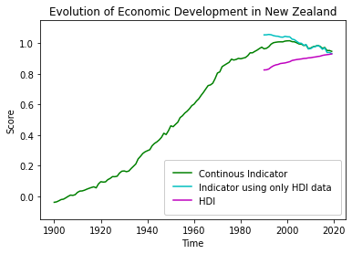

```python
is_NZ = table_final_rbf_r.country=="New Zealand"
NZ=table_final_rbf_r[is_NZ]

is_NZ2= final_gaussian.Country==" New Zealand"
NZ2=final_gaussian[is_NZ2]


plt.plot(NZ.year, NZ.Score_HDI_SVM_rbf_r, 'g', label="Continous Indicator")
plt.plot(NZ2.Year, NZ2.Score_2, 'c', label="Indicator using only HDI data")
plt.plot(NZ.year, NZ.HDI_score, 'm', label="HDI")
plt.legend(fancybox=True, framealpha=1, borderpad=1)
plt.title('Evolution of Economic Development in New Zealand')
plt.xlabel('Time')
plt.ylabel('Score')
plt.ylim((-0.15,1.15))
```

### Australia

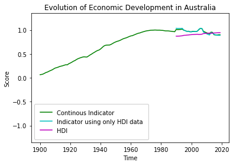

```python
is_Australia= table_final_rbf_r.country=="Australia"
Australia=table_final_rbf_r[is_Australia]

is_Australia2= final_gaussian.Country==" Australia"
Australia2=final_gaussian[is_Australia2]


plt.plot(Australia.year, Australia.Score_HDI_SVM_rbf_r, 'g', label="Continous Indicator")
plt.plot(Australia2.Year, Australia2.Score_2, 'c', label="Indicator using only HDI data")
plt.plot(Australia.year, Australia.HDI_score, 'm', label="HDI")
plt.legend(fancybox=True, framealpha=1, borderpad=1)
plt.title('Evolution of Economic Development in Australia')
plt.xlabel('Time')
plt.ylabel('Score')
plt.ylim((-1.35,1.35))
```